# Typology

Aniko B Toth

07/08/2020

### Habitat classifications

Habitat classifications were based on a consensus approach (100 cmeans runs) using abiotic data.

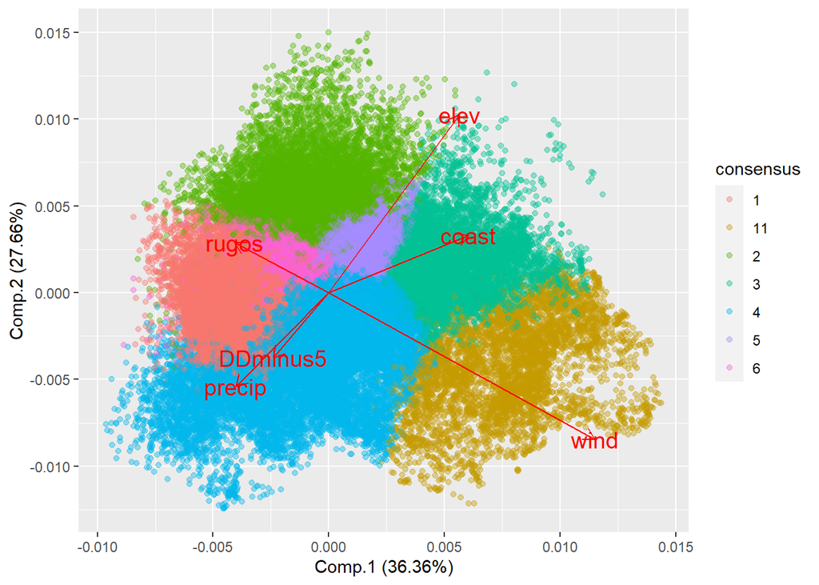

Approximate habitat descriptions (very pronounced features in **bold**):

1: high rugosity, lower **elevation**, low **wind**.

2: high **rugosity**, high **elevation**, low wind.

3: high elevation, **inland**, windy, dry, very cold

4: high **precipitation**, coastal, low elevation, **warmer**

5: medium elevation and rugosity, but higher elevation and lower rugosity than cluster 6, inland, very cold

6: medium elevation and rugosity, lower wind, near coastal

11: extremely **windy**, usually lower rugosity, very low precip

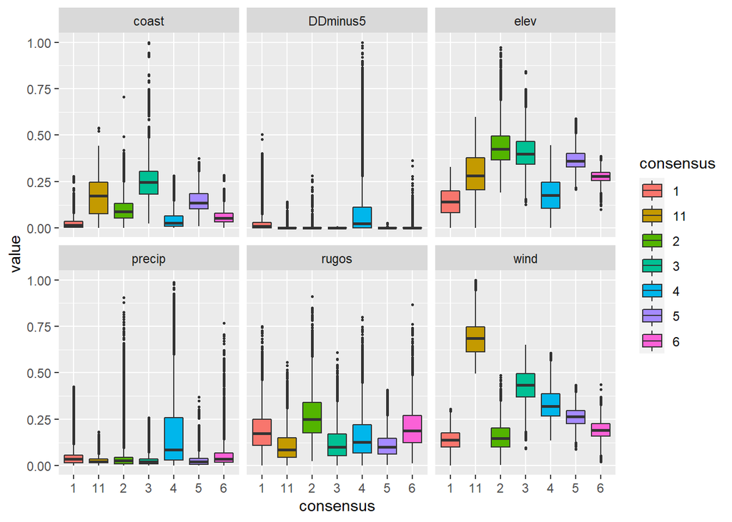

### Typology units

The habitats were then split into ACBRs, creating a rudimentary typology. These ACBR-habitat units were then lumped by similarity based on species point occurrences. Several combinations of ACBR-habitat do not exist, and several are represented by very few pixels.

```
##
##                                        1   11    2    3    4    5    6
##   Adelie Land                          6   50    0    0  137    0    0
##   Central south Antarctic Peninsula 2418    0  319   57 3850  497  524
##   Dronning Maud Land                  29 1909   47 2147  249   65    0
##   East Antarctica                      0   62    0    0  352    0    0
##   Ellsworth Land                       0    9    0    0  276    0    0
##   Ellsworth Mountains                214    2  486  350  621  295  115
##   Enderby Land                        19  290    0  213 1218    2    1
##   Marie Byrd Land                    164   10   15  282  864    3    0
##   North-east Antarctic Peninsula      39    0    2    0  814    0    3
##   North-west Antarctic Peninsula     454    0  100    0 5024    0   97
##   North Victoria Land               2540  101 3984  472  951 1024  907
##   Prince Charles Mountains           109 2018    3  178  752   20   49
##   South Antarctic Peninsula         1615    2    8  151 1050  350  576
##   South Victoria Land               2334   33  922  272  640  474  401
##   Transantarctic Mountains          1835  520 4306 2809 2344 1491  617
```

### Classifying pixels without abiotic data

Unclassified pixels were classified in the following way:

Pixels covering offshore islands were classified by island size:

Small islands: 0-1 km^^2 Medium islands: 1-100 km^^2 Large islands*: 100+ km^^2

*A caveat here is that large islands usually have habitats classified within them, meaning “Large islands” pixels are usually just coastal/offshore pixels of large islands. Possibly these should be classified using the nearest units instead.

Unclassified pixels on or near the coast of the mainland were classified using the nearest typological units (max 6km away).

Remaining unclassified pixels were classified based on SDM-based similarity and spatial proximity (max 100 km but min 0.98 similarity) to existing units. About 250 pixels remain unclassified (these didn’t have a similar unit close enough).

### Typology V1

Below is a very terrible map of the output raster. See the actual raster file in arcGIS to get a better picture.

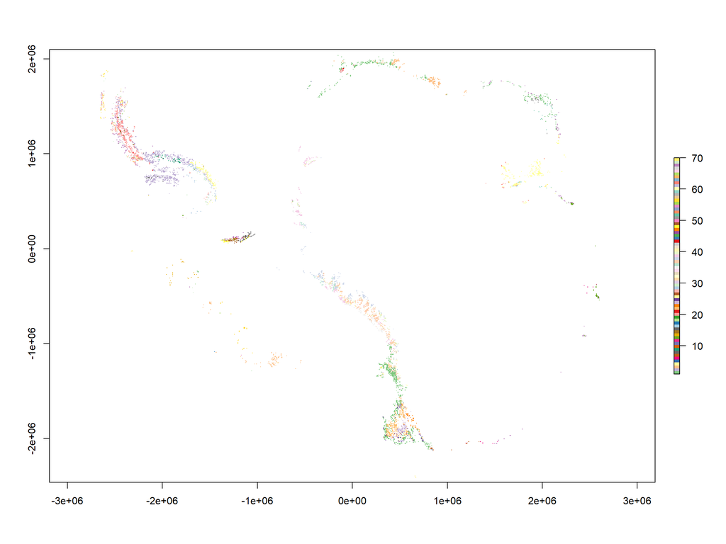

The below table is a key for the raster levels (1-70). It shows the ACBR-habitat combination and which unit its assigned to, as well as the number of pixels in each.

```
## # A tibble: 84 x 3
## # Groups:   unit [84]
##    unit                                consensus2 pixels
##    <chr>                                    <dbl>  <int>
##  1 Dronning Maud Land_3                         1   2339
##  2 Dronning Maud Land_4                         1    283
##  3 Enderby Land_4                               1   1390
##  4 North Victoria Land_1                        1   2789
##  5 North Victoria Land_4                        1    985
##  6 South Victoria Land_1                        1   2437
##  7 South Victoria Land_4                        1    660
##  8 Central south Antarctic Peninsula_1          2   2453
##  9 Central south Antarctic Peninsula_4          2   3878
## 10 Central south Antarctic Peninsula_6          2    524
## 11 North-east Antarctic Peninsula_4             2    894
```

[output cut: 73 more lines]

Notes on V1 of the typology:

This typology is oversplit. We need expert input to try to work out which units could be lumped. Part of this is working out whether we would rather group somewhat similar habitats in the same spatial area, or the same habitats in disparate ACBRs. Some of the units are VERY small (fewer than 20 pixels). Decisions need to be made whether these should be dropped, lumped with nearby habitats, or lumped with similar habitats farther away. I looked at some of these tiny units in Google Earth, and the habitat distinctions seemed legitimate, usually because in mountainous areas the habitat can change rapidly (e.g. a valley vs a cliff vs a ridgetop), therefore personally I think I’m more in favour of the latter idea.

It is possible that some big lumped typological units should be un-lumped, these were usually lumped based on faunal similarity, and difference from the rest of the units on a continental scale. Possibly the finer delineations within these lumped units ought to be recognised.

Alternatively, it is possible to repeat the typology creation process using my code, but using e.g. fewer cmeans centres to start with (resulting likely in fewer habitats), and use less stringent criteria when lumping/classifying units.